# ExtraaLearn Project

## Context

The EdTech industry has been surging in the past decade immensely, and according to a forecast, the Online Education market would be worth $286.62bn by 2023 with a compound annual growth rate (CAGR) of 10.26% from 2018 to 2023. The modern era of online education has enforced a lot in its growth and expansion beyond any limit. Due to having many dominant features like ease of information sharing, personalized learning experience, transparency of assessment, etc, it is now preferable to traditional education.

In the present scenario due to the Covid-19, the online education sector has witnessed rapid growth and is attracting a lot of new customers. Due to this rapid growth, many new companies have emerged in this industry. With the availability and ease of use of digital marketing resources, companies can reach out to a wider audience with their offerings. The customers who show interest in these offerings are termed as leads. There are various sources of obtaining leads for Edtech companies, like

- The customer interacts with the marketing front on social media or other online platforms.
- The customer browses the website/app and downloads the brochure
- The customer connects through emails for more information.

The company then nurtures these leads and tries to convert them to paid customers. For this, the representative from the organization connects with the lead on call or through email to share further details.

## Objective

ExtraaLearn is an initial stage startup that offers programs on cutting-edge technologies to students and professionals to help them upskill/reskill. With a large number of leads being generated on a regular basis, one of the issues faced by ExtraaLearn is to identify which of the leads are more likely to convert so that they can allocate resources accordingly. You, as a data scientist at ExtraaLearn, have been provided the leads data to:

- Analyze and build an ML model to help identify which leads are more likely to convert to paid customers,
- Find the factors driving the lead conversion process
- Create a profile of the leads which are likely to convert

## Data Description

The data contains the different attributes of leads and their interaction details with ExtraaLearn. The detailed data dictionary is given below.

**Data Dictionary**

- ID: ID of the lead
- age: Age of the lead
- current_occupation: Current occupation of the lead. Values include 'Professional','Unemployed',and 'Student'
- first_interaction: How did the lead first interacted with ExtraaLearn. Values include 'Website', 'Mobile App'
- profile_completed: What percentage of profile has been filled by the lead on the website/mobile app. Values include Low - (0-50%), Medium - (50-75%), High (75-100%)
- website_visits: How many times has a lead visited the website
- time_spent_on_website: Total time spent on the website
- page_views_per_visit: Average number of pages on the website viewed during the visits.
- last_activity: Last interaction between the lead and ExtraaLearn.
  - Email Activity: Seeking for details about program through email, Representative shared information with lead like brochure of program , etc
  - Phone Activity: Had a Phone Conversation with representative, Had conversation over SMS with representative, etc
  - Website Activity: Interacted on live chat with representative, Updated profile on website, etc
- print_media_type1: Flag indicating whether the lead had seen the ad of ExtraaLearn in the Newspaper.
- print_media_type2: Flag indicating whether the lead had seen the ad of ExtraaLearn in the Magazine.
- digital_media: Flag indicating whether the lead had seen the ad of ExtraaLearn on the digital platforms.
- educational_channels: Flag indicating whether the lead had heard about ExtraaLearn in the education channels like online forums, discussion threads, educational websites, etc.
- referral: Flag indicating whether the lead had heard about ExtraaLearn through reference.
- status: Flag indicating whether the lead was converted to a paid customer or not.

## Importing necessary libraries and data

```python
# Importing the basic libraries we will require for the project

# Libraries to help with reading and manipulating data
import pandas as pd
import numpy as np

# Libaries to help with data visualization
import matplotlib.pyplot as plt
import seaborn as sns
sns.set()

# Importing the Machine Learning models we require from Scikit-Learn
from sklearn.linear_model import LogisticRegression
from sklearn.svm import SVC
from sklearn.tree import DecisionTreeClassifier
from sklearn import tree
from sklearn.ensemble import RandomForestClassifier

# Importing the other functions we may require from Scikit-Learn
from sklearn.model_selection import train_test_split, GridSearchCV
from sklearn.preprocessing import MinMaxScaler, LabelEncoder, OneHotEncoder
from sklearn.impute import SimpleImputer

# To get diferent metric scores
from sklearn import metrics
from sklearn.metrics import confusion_matrix,classification_report,roc_auc_score,precision_recall_curve,roc_curve,make_scorer, recall_score

# Code to ignore warnings from function usage
import warnings;
import numpy as np
warnings.filterwarnings('ignore')
```

```python
# Loading the data from the Google Drive

# Mount Google Drive
from google.colab import drive
drive.mount('/content/drive')

# Loading the dataset
data=pd.read_csv("/content/drive/MyDrive/Python Course/Classification/ExtraaLearn.csv")
```

### Data Overview

- Observations
- Sanity checks

#### View the first and last rows of the dataset

Understand the structure of the data set and example data points

```python
# Review the first 5 rows of the data
data.head()
```

|  | ID | age | current_occupation | first_interaction | profile_completed | website_visits | time_spent_on_website | page_views_per_visit | last_activity | print_media_type1 | print_media_type2 | digital_media | educational_channels | referral | status |
| --- | --- | --- | --- | --- | --- | --- | --- | --- | --- | --- | --- | --- | --- | --- | --- |
| 0 | EXT001 | 57 | Unemployed | Website | High | 7 | 1639 | 1.861 | Website Activity | Yes | No | Yes | No | No | 1 |
| 1 | EXT002 | 56 | Professional | Mobile App | Medium | 2 | 83 | 0.320 | Website Activity | No | No | No | Yes | No | 0 |
| 2 | EXT003 | 52 | Professional | Website | Medium | 3 | 330 | 0.074 | Website Activity | No | No | Yes | No | No | 0 |
| 3 | EXT004 | 53 | Unemployed | Website | High | 4 | 464 | 2.057 | Website Activity | No | No | No | No | No | 1 |
| 4 | EXT005 | 23 | Student | Website | High | 4 | 600 | 16.914 | Email Activity | No | No | No | No | No | 0 |

```python
# Review the last 5 rows of the data

data.tail()
```

|  | ID | age | current_occupation | first_interaction | profile_completed | website_visits | time_spent_on_website | page_views_per_visit | last_activity | print_media_type1 | print_media_type2 | digital_media | educational_channels | referral | status |
| --- | --- | --- | --- | --- | --- | --- | --- | --- | --- | --- | --- | --- | --- | --- | --- |
| 4607 | EXT4608 | 35 | Unemployed | Mobile App | Medium | 15 | 360 | 2.170 | Phone Activity | No | No | No | Yes | No | 0 |
| 4608 | EXT4609 | 55 | Professional | Mobile App | Medium | 8 | 2327 | 5.393 | Email Activity | No | No | No | No | No | 0 |
| 4609 | EXT4610 | 58 | Professional | Website | High | 2 | 212 | 2.692 | Email Activity | No | No | No | No | No | 1 |
| 4610 | EXT4611 | 57 | Professional | Mobile App | Medium | 1 | 154 | 3.879 | Website Activity | Yes | No | No | No | No | 0 |
| 4611 | EXT4612 | 55 | Professional | Website | Medium | 4 | 2290 | 2.075 | Phone Activity | No | No | No | No | No | 0 |

Based on a general view of the data we can see that there is a mix between continuous and categorical variables. We have a potential customer ID variable, which I expect to be unique for each data point. This variable will likely not be useful for our learning models, however, it is helpful to maintain a copy with this identifier for future cases where we might want to map against other data that may be collected in the future.

#### Understand the shape of the dataset and check data types

```python
data.shape
```

```
(4612, 15)
```

The dataset has 4612 rows and 15 columns

```python
data.info()
```

```
<class 'pandas.core.frame.DataFrame'>
RangeIndex: 4612 entries, 0 to 4611
Data columns (total 15 columns):
 #   Column                 Non-Null Count  Dtype
---  ------                 --------------  -----
 0   ID                     4612 non-null   object
 1   age                    4612 non-null   int64
 2   current_occupation     4612 non-null   object
 3   first_interaction      4612 non-null   object
 4   profile_completed      4612 non-null   object
 5   website_visits         4612 non-null   int64
 6   time_spent_on_website  4612 non-null   int64
 7   page_views_per_visit   4612 non-null   float64
 8   last_activity          4612 non-null   object
 9   print_media_type1      4612 non-null   object
 10  print_media_type2      4612 non-null   object
 11  digital_media          4612 non-null   object
 12  educational_channels   4612 non-null   object
 13  referral               4612 non-null   object
 14  status                 4612 non-null   int64
dtypes: float64(1), int64(4), object(10)
memory usage: 540.6+ KB
```

Based on the general information of the dataset we can see that there appear to be:

- 1 float variable (page views per visit)
- 4 integers (age, website visits, time spent on website, and status)
- 10 pandas data objects (occupation, first interaction, profile completed, last activity, print media type 1, print media type 2, digital media, educational channels, and referral)

`status` is an integer, however, based on our description of variables we know that this is a flag and should be considered as a categorical variable rather than a continuous variable.

From the null count there do not appear to be any null variables, which may reduce our need to impute any missing variables, reducing the risk of inserting bias in the model and increasing our confidence in our features.

```python
# confirm the possibility of missing values
pd.DataFrame(data={'# of Missing Values':round(data.isna().sum())}).sort_values(by='# of Missing Values',ascending=False)
```

|  | # of Missing Values |
| --- | --- |
| ID | 0 |
| age | 0 |
| current_occupation | 0 |
| first_interaction | 0 |
| profile_completed | 0 |
| website_visits | 0 |
| time_spent_on_website | 0 |
| page_views_per_visit | 0 |
| last_activity | 0 |
| print_media_type1 | 0 |
| print_media_type2 | 0 |
| digital_media | 0 |
| educational_channels | 0 |
| referral | 0 |
| status | 0 |

Based on the output above we confirm that there are no missing values in the data set.

```python
# Check the number of unique values in the dataset

data.nunique()
```

```
ID                       4612
age                        46
current_occupation          3
first_interaction           2
profile_completed           3
website_visits             27
time_spent_on_website    1623
page_views_per_visit     2414
last_activity               3
print_media_type1           2
print_media_type2           2
digital_media               2
educational_channels        2
referral                    2
status                      2
dtype: int64
```

As seen above we confirm that `status` is a categorical variable with two options.

The continuous variables in the dataset are `age`, `website_visits`, `time_spent_on_website`, and `page_views_per_visit`

#### Create a copy of the data set and drop the ID column

```python
# Create a copy of the data
df = data.copy()
```

```python
# Drop the unique ID

df.drop(columns = 'ID', inplace=True)
```

```python
# Check for duplicated rows

df.duplicated().sum()
```

```
14
```

```python
data.duplicated().sum()
```

```
0
```

Because in the original data set (with unique identifier) the data is not duplicated, I think that it is reasonable that 14 leads may have the same features selected. The features we are looking at are general enough that it is possible that among the sample 14 leads have the same features.

#### Review the summary statistics of the data set

```python
# describe the summary statistics - transposed so that features show as the rows to facilitate review

df.describe().T # Summary statistics of continuous variables (Note status is technically categorical)
```

|  | count | mean | std | min | 25% | 50% | 75% | max |
| --- | --- | --- | --- | --- | --- | --- | --- | --- |
| age | 4612.0 | 46.201214 | 13.161454 | 18.0 | 36.00000 | 51.000 | 57.00000 | 63.000 |
| website_visits | 4612.0 | 3.566782 | 2.829134 | 0.0 | 2.00000 | 3.000 | 5.00000 | 30.000 |
| time_spent_on_website | 4612.0 | 724.011275 | 743.828683 | 0.0 | 148.75000 | 376.000 | 1336.75000 | 2537.000 |
| page_views_per_visit | 4612.0 | 3.026126 | 1.968125 | 0.0 | 2.07775 | 2.792 | 3.75625 | 18.434 |
| status | 4612.0 | 0.298569 | 0.457680 | 0.0 | 0.00000 | 0.000 | 1.00000 | 1.000 |

```python
# Measuring 1.5 IQR rule for time spent on website
mean = 724.011275
Q1 = 148.75000
Q2 = 376.000
Q3 = 1336.75000
maxx =	2537.000

Q3 + 1.5*(Q3 - Q1)
```

```
3118.75
```

From the initial summary statistics we can infer the following points for each continuous variable:

`age` - There is a slight left skew in the data as the mean is 46.2 whereas the median is 51. This is likely an indication that the audience is generally older, which aligns with our target audience of experienced professionals looking to upskill / reskill. This indication can also be seen as positive since younger people generally have less buying power.

`time_spent_on_website` - There appears to be a right skew in the data as the mean is 724.01, whereas the median is 376. There may also be a presence of outliers, however, the maximum is not greater than 1.5 IQR as there is a pretty large standard deviation. Depending on the EDA we will understand whether any manipulation should be completed.

`page_views_per_visit` - There appears to be minimal right skew on this variable, however, due to the maximum 18.434 where the mean is 3.03 and the standard deviation is 1.97 we expect there to be outliers in this variable.

```python
# preparing categorical variables to understand unique count of values

# Create a list of all categorical variable columns
cat_col = ['current_occupation','first_interaction', 'profile_completed','last_activity','print_media_type1','print_media_type2','digital_media','educational_channels','referral','status']

# Print the number of count of each unique value in each column
for column in cat_col:
  print(df[column].value_counts())
  print('\n Percentages: \n')
  print(df[column].value_counts(normalize = True).apply(lambda x: f'{x:.0%}'))
  print('-'*50)
```

```
Professional    2616
Unemployed      1441
Student          555
Name: current_occupation, dtype: int64

 Percentages:

Professional    57%
Unemployed      31%
Student         12%
Name: current_occupation, dtype: object
--------------------------------------------------
Website       2542
Mobile App    2070
Name: first_interaction, dtype: int64

 Percentages:

Website       55%
Mobile App    45%
Name: first_interaction, dtype: object
--------------------------------------------------
High      2264
Medium    2241
Low        107
Name: profile_completed, dtype: int64

 Percentages:

High      49%
Medium    49%
Low        2%
Name: profile_completed, dtype: object
--------------------------------------------------
Email Activity      2278
Phone Activity      1234
Website Activity    1100
Name: last_activity, dtype: int64

 Percentages:
```

[output cut: 51 more lines]

```

No     98%
Yes     2%
Name: referral, dtype: object
--------------------------------------------------
0    3235
1    1377
Name: status, dtype: int64

 Percentages:

0    70%
1    30%
Name: status, dtype: object
--------------------------------------------------
```

Based on the initial analysis of the distribution of our categorical variables we can see that:

`current_occupation` - 57% of engagement is from Professionals, which means they likely have more spending power compared to the Unemployed and Student population. The Student population is only 12%, which aligns with our initial observation that the age distribution is generally higher. A 31% distribution of Unemployed searchers is also significant as they will likely have more time to dedicate to the course and may be willing to make the purchase.

`first_interaction` - The Website and Mobile App do not have significantly different distributions in the sample, however, it is clear that the website drives more traffic than the Mobile App. This may be due to the element of having to download a Mobile App in order to use it as opposed to using the website on the browser - there is less friction related to interacting with the Website.

`profile_completed` - 98% of our dataset has at least Medium complete profile with only 2% of observations in Low complete status. Higher completion may be preferrable as it demonstrates greater interest and investment by taking the time to complete the profile.

`last_activity` - 49% of the data has a last activity through the Email channel, which allows for more opportunities to provide information in the form of attachments and follow-up communications.

**Marketing Channels**

- `print_media_type1` - 11% of our sample saw the ad in the newspaper.
- `print_media_type2` - 5% of our sample saw the ad in Magazines.
- `digital_media`- 11% of our sample saw the ad through digital channels.
- `educational_channels` - 15% of our sample saw the ad through educational channels.
  - It appears that Newspapers and Digital channels had similar rates of impressions and lead generation
  - Magazines had less success in generating leads
  - Newspapers may be preforming well due to the age distribution of leads
  - There may be an opportunity to increase penetration of digital media as there should be less friction surrounding converting a digital ad into a lead
  - Educational channels had the best penetration, which may be expected as the target audience would likely be interacting with these channels

`referral` - only 2% of leads came from referrals. There is a positive that marketing initiatives are successfully reaching new users, however, word of mouth is known to be a powerful driver for decision-making so understanding the satisfaction of current users and how to improve the product could be a good strategy for increasing referrals and lead conversions.

`status` - about 30% of leads were converted, which represents an opportunity for improvement. This will be the dependent variable that we will use in our models, which we can see is *imbalanced*.

```python
# Covert the data type of categorical variables to 'category'
for column in cat_col:
  df[column] = df[column].astype('category')
```

```python
df.info()
```

```
<class 'pandas.core.frame.DataFrame'>
RangeIndex: 4612 entries, 0 to 4611
Data columns (total 14 columns):
 #   Column                 Non-Null Count  Dtype
---  ------                 --------------  -----
 0   age                    4612 non-null   int64
 1   current_occupation     4612 non-null   category
 2   first_interaction      4612 non-null   category
 3   profile_completed      4612 non-null   category
 4   website_visits         4612 non-null   int64
 5   time_spent_on_website  4612 non-null   int64
 6   page_views_per_visit   4612 non-null   float64
 7   last_activity          4612 non-null   category
 8   print_media_type1      4612 non-null   category
 9   print_media_type2      4612 non-null   category
 10  digital_media          4612 non-null   category
 11  educational_channels   4612 non-null   category
 12  referral               4612 non-null   category
 13  status                 4612 non-null   category
dtypes: category(10), float64(1), int64(3)
memory usage: 190.5 KB
```

## Exploratory Data Analysis (EDA)

- EDA is an important part of any project involving data.
- It is important to investigate and understand the data better before building a model with it.
- A few questions have been mentioned below which will help you approach the analysis in the right manner and generate insights from the data.
- A thorough analysis of the data, in addition to the questions mentioned below, should be done.

#### Univariate Analysis

##### Plotting the Distribution of Continuous Variables

`age`  
`website_visits`  
`time_spent_on_website`  
`page_views_per_visit`

```python
# Define hist_box() function to view both a histogram and boxplot in the same visual

def hist_box(df, col):
  f, (ax_box, ax_hist) = plt.subplots(2, sharex=True, gridspec_kw={'height_ratios':(0.15,.850)}, figsize=(12,6))
  # Add a graph in each part
  sns.boxplot(data = df, x=col, ax = ax_box, showmeans=True, color = 'mintcream')
  sns.histplot(data = df, x=col, kde=True, ax=ax_hist)
  ax_hist.axvline(df[col].mean(), color = 'green', linestyle = '--')
  ax_hist.axvline(df[col].median(), color = 'black', linestyle = "-")

  plt.show()
```

###### `age`

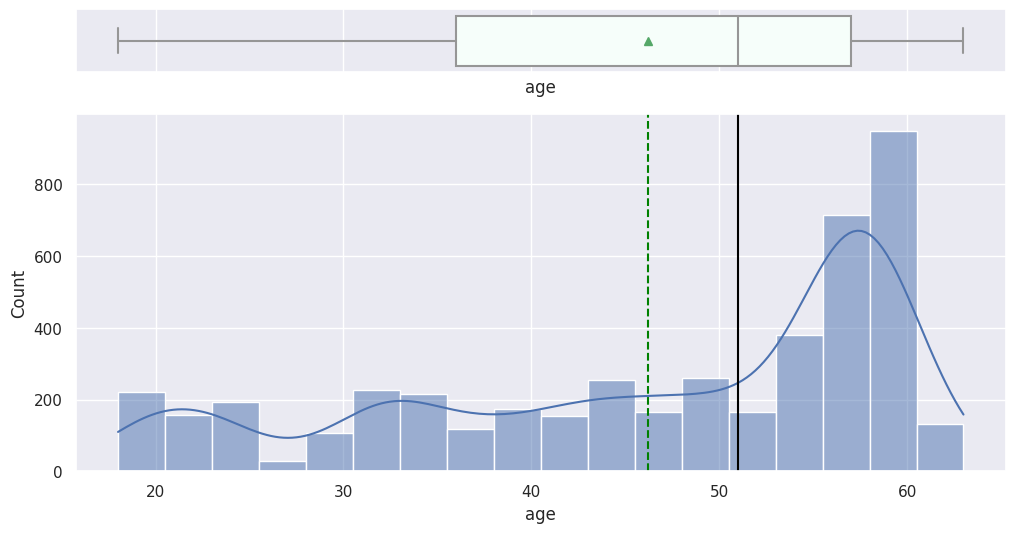

```python
hist_box(df,'age')
```

- The distribution of the age data shows the left skew that was expected with a mode in the high fifties. There seem to be some small modes especially around the beginning of decades, which can indicate people's desire to make life changes or upskilling when entering new life stages.
- It will be interesting to understand in the bivariate analysis how age plays a role in conversion to see if the right demographic is being targeted with current marketing campaigns given that there is only a 30% conversion at the moment.

###### `website_visits`

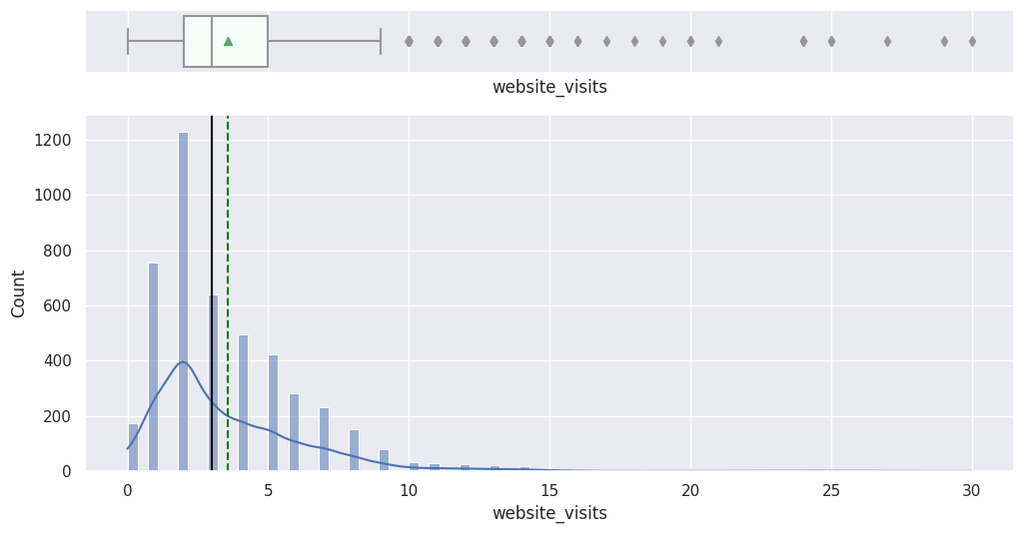

```python
hist_box(df,'website_visits')
```

```python
web_visit_outliers = df['website_visits'] > 9
web_visit_outliers.sum()
```

```
154
```

```python
154/4612
```

```
0.03339115351257589
```

```python
web_outliers = df['website_visits'] > 15
web_outliers.sum()
```

```
17
```

###### `time_spent_on_website`

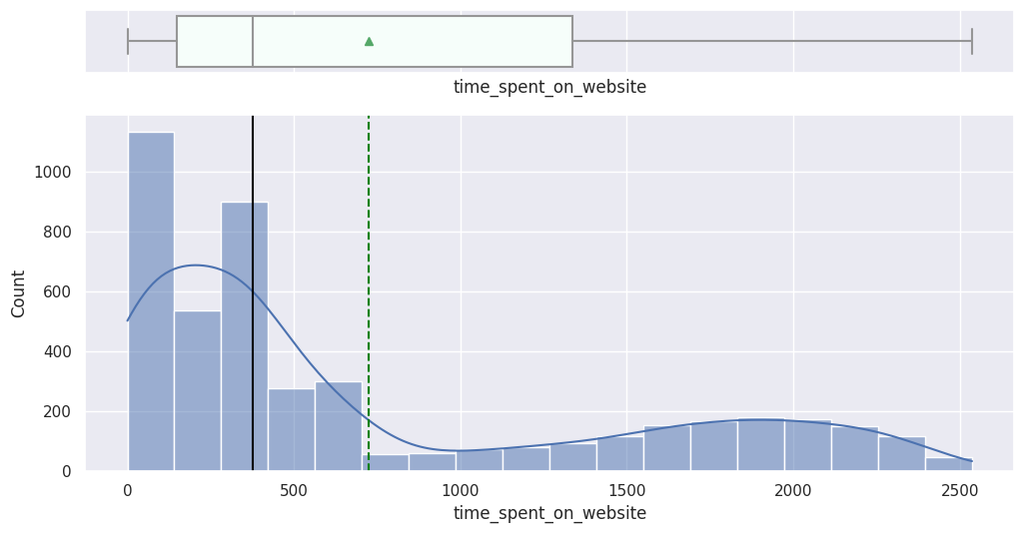

```python
hist_box(df,'time_spent_on_website')
```

- The data appears to have a bi-modal tendency with a clear mode below the median
- As we saw in our original outlier calculations, the graph does not detect any clear outliers in this feature due to the large standard deviation

###### `page_views_per_visit`

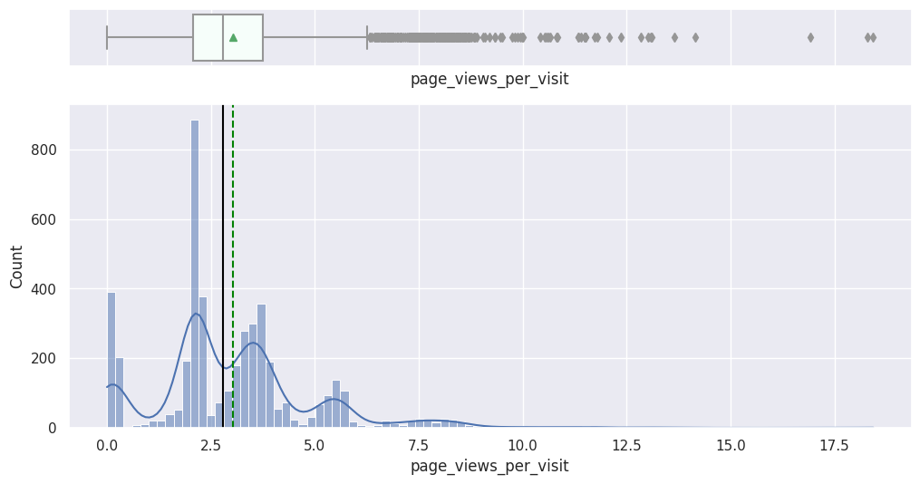

```python
hist_box(df,'page_views_per_visit')
```

```python
page_views_outliers = df['page_views_per_visit'] > 6.5
page_views_outliers.sum()
```

```
250
```

```python
page_outliers = df['page_views_per_visit'] > 10
web_outliers.sum()
page_outliers.sum()
```

```
27
```

- The distribution of average pages viewed per visit also has multiple modes with a distinct mode around 2 pages per visit.
- The distribution detects 250 outliers, which similar to the website traffic could significantly affect our data
- There is the potential to amend the outlier threshold to 10 reducing the outliers for removal to 27

##### Plotting the Distribution of Categorical Variables

`current_occupation`  
`first_interaction`  
`profile_completed`  
`last_activity`  
`print_media_type1`  
`print_media_type2`  
`digital_media`  
`educational_channels`  
`referral`  
`status`

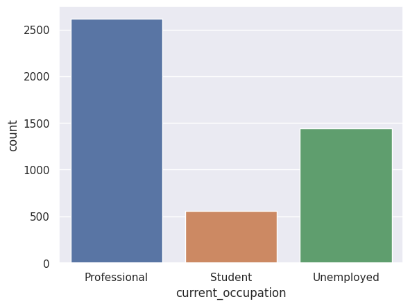

```
 Professional    0.567216
Unemployed      0.312446
Student         0.120338
Name: current_occupation, dtype: float64
```

```python
sns.countplot(x=df['current_occupation'])
plt.show()
print('\n',df['current_occupation'].value_counts(normalize=True))
```

- Over 50% of the sample is made up of Professionals

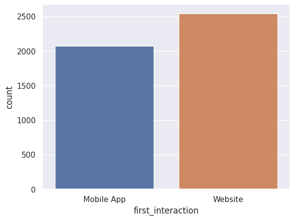

```
 Website       0.551171
Mobile App    0.448829
Name: first_interaction, dtype: float64
```

```python
sns.countplot(x = df['first_interaction'])
plt.show()
print('\n',df['first_interaction'].value_counts(normalize=True))
```

- 55% of first interactions is through the website, which is important to consider if we want to improve the first interactions with leads

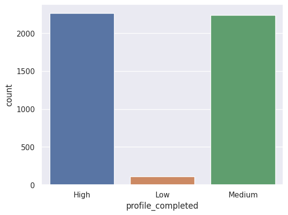

```
 High      0.490893
Medium    0.485906
Low       0.023200
Name: profile_completed, dtype: float64
```

```python
sns.countplot(x = df['profile_completed'])
plt.show()
print('\n',df['profile_completed'].value_counts(normalize=True))
```

- Over 98% of leads took the time to complete at least Medium status of the profile

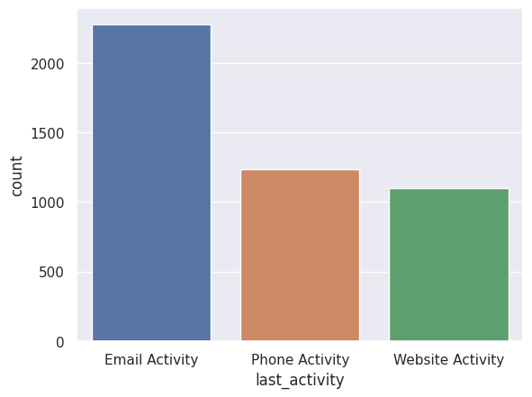

```
 Email Activity      0.493929
Phone Activity      0.267563
Website Activity    0.238508
Name: last_activity, dtype: float64
```

```python
sns.countplot(x=df['last_activity'])
plt.show()
print('\n',df['last_activity'].value_counts(normalize=True))
```

- Almost half of leads engage with the company via Email communication

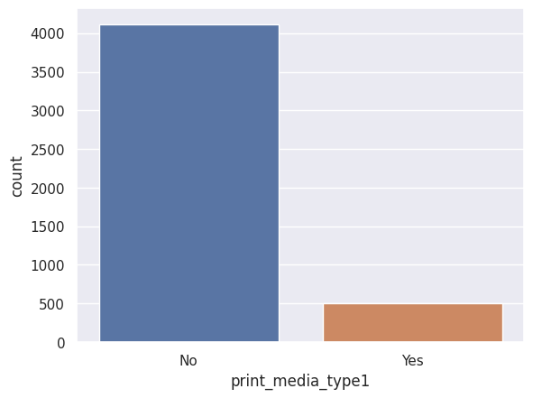

```
 No     0.892238
Yes    0.107762
Name: print_media_type1, dtype: float64
```

```python
sns.countplot(x = df['print_media_type1'])
plt.show()
print('\n',df['print_media_type1'].value_counts(normalize=True))
```

- About 11% of leads encountered ads through Newspaper

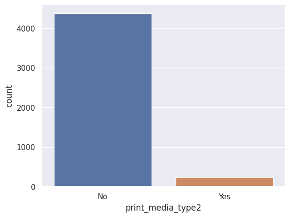

```
 No     0.94948
Yes    0.05052
Name: print_media_type2, dtype: float64
```

```python
sns.countplot(x=df['print_media_type2'])
plt.show()
print('\n',df['print_media_type2'].value_counts(normalize=True))
```

- About 5% of leads saw an ad in Magazines

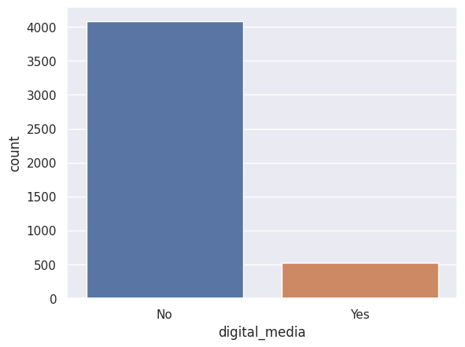

```
 No     0.885733
Yes    0.114267
Name: digital_media, dtype: float64
```

```python
sns.countplot(x=df['digital_media'])
plt.show()
print('\n',df['digital_media'].value_counts(normalize=True))
```

- About 11% of leads saw an ad through digital media channels

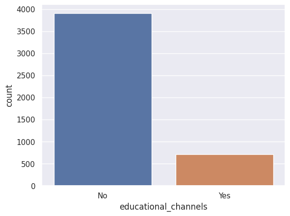

```
 No     0.847138
Yes    0.152862
Name: educational_channels, dtype: float64
```

```python
sns.countplot(x=df['educational_channels'])
plt.show()
print('\n',df['educational_channels'].value_counts(normalize=True))
```

- About 15% of leads encountered ads in educational channels

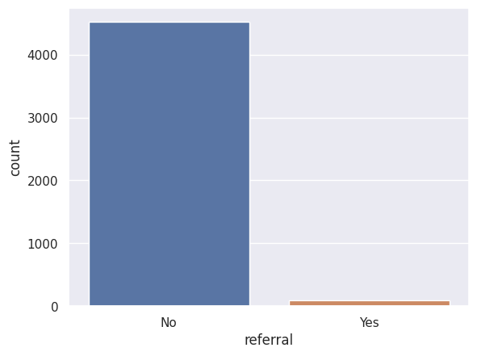

```
 No     0.979835
Yes    0.020165
Name: referral, dtype: float64
```

```python
sns.countplot(x=df['referral'])
plt.show()
print('\n',df['referral'].value_counts(normalize=True))
```

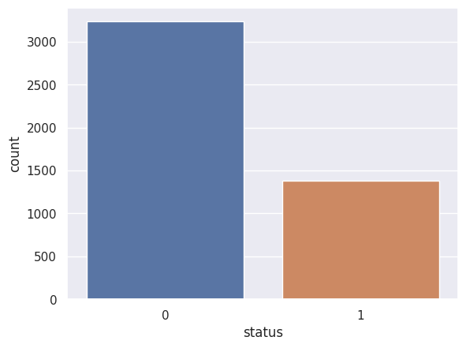

```
 0    0.701431
1    0.298569
Name: status, dtype: float64
```

```python
sns.countplot(x=df['status'])
plt.show()
print('\n',df['status'].value_counts(normalize=True))
```

#### Bivariate Analysis

###### Continuous Variables

```python
# Using a heatmap to determine the correlation between continuous variables

cols_list = df.select_dtypes(include=np.number).columns.tolist()

plt.figure(figsize=(12, 7))
sns.heatmap(data[cols_list].corr(), annot=True, vmin=-1, vmax=1, fmt=".2f", cmap="Spectral")
plt.show()
```

[output not shown]

###### Categorical Variables

```python
# Define the stacked barplot function

def stacked_barplot(data, predictor, target, figsize=(5, 3)):
    # Create a crosstab with percentages
    crosstab = (pd.crosstab(data[predictor], data[target], normalize='index') * 100)

    # Create the stacked barplot
    ax = crosstab.plot(kind='bar', figsize=figsize, stacked=True)

    # Add percentage labels on top of the bars
    for container in ax.containers:
        ax.bar_label(container, fmt='%.2f%%', label_type='edge', fontsize = 7)

    plt.legend(loc='lower right')
    plt.ylabel(target)
    plt.show()
```

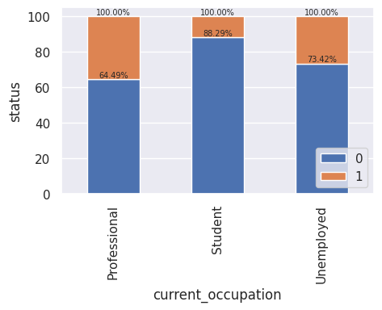

```python
stacked_barplot(df,"current_occupation","status")
```

- Professionals had the highest conversion rate confirming that users of the product likely have a higher spending capacity to pay for it. This also tells us that it will be important for marketing materials to highlight that it is designed to be done at the same time as a full time job
- Unemployed professionals had the second highest conversion rate, which indicates that the program should also explain the benefits to securing a new position in the area of interest
- Students had the lowest conversion rate

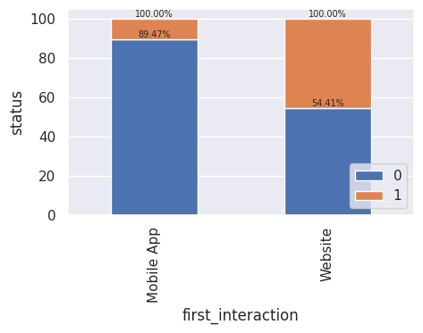

```python
stacked_barplot(df,"first_interaction","status")
```

- Leads with the website as the first interaction had the highest conversion rate
  - this is positive considering that a higher percentage of leads interacted with the website first
  - the low conversion rate (around 10%) on the Mobile App indicates need for improvement on the Mobile App experience and marketing materials as 45% of the sample had a first impression on the app

```python
print('Mobile App Conversion = ', 100-89.47)
print('Website Conversion = ', 100-54.41)
```

```
Mobile App Conversion =  10.530000000000001
Website Conversion =  45.59
```

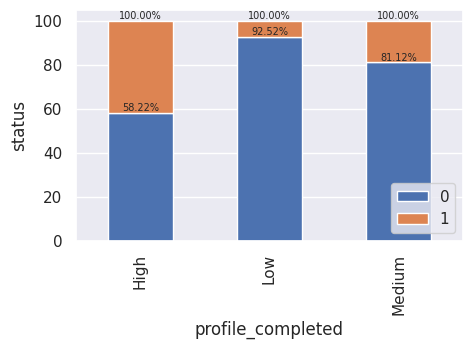

```python
stacked_barplot(df,"profile_completed","status")
```

- Leads that had high profile completion had the highest conversion rate, which can indicate that investing in adding personal data to the profile is related to the seriousness of the lead
- Low and Medium profile completions had low conversion rates, which may indicate that there is critical information that these leads are not receiving that could lead to conversions due to the lack of a complete profile

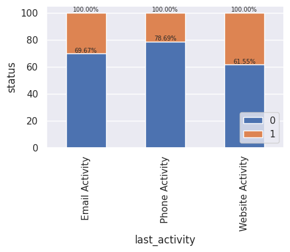

```python
stacked_barplot(df,"last_activity","status")
```

- Website Activity had the highest conversion rate despite being the channel that had the least amount of observations in the sample
  - the live chat feature may be driving conversion as questions are resolved in real-time
  - further investigation could be done to understand why email and phone activity, which have higher number of observations are not driving more conversions

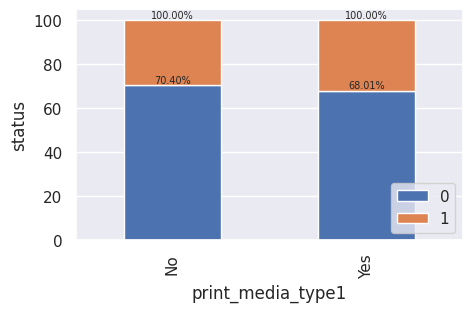

```python
stacked_barplot(df,"print_media_type1","status")
```

- Interaction with Newspaper Ads does not seem to be a big factor in determining conversion as the rates are similar for both categories
- This is one of the channels with higher impressions so it could be further analyzed and improved - though there is a lightly higher percent of conversions from these ads

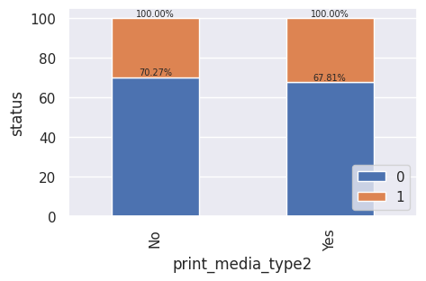

```python
stacked_barplot(df,"print_media_type2","status")
```

- Similar to Newspaper Ads, Magazine ads do not seem to be a key driver in conversions
- This was the channel with the lowest impressions, however, it was the channel that had the highest conversion rate (except for referrals)

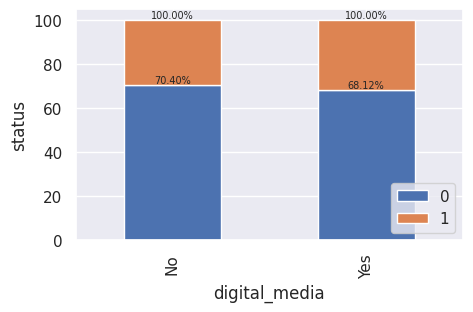

```python
stacked_barplot(df,"digital_media","status")
```

- Digital media channel also does not seem to be driving conversions
- There is still the opporuntity to drive higher volume of impressions with links as it is currently on par with Newspaper ads in impressions which could lead to more conversion as this channel is further developed

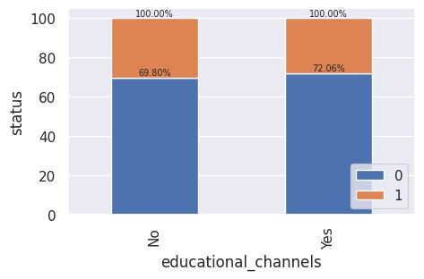

```python
stacked_barplot(df,"educational_channels","status")
```

- Educational channels also does not seem to be a critical factor in driving conversions, and in fact, the % of conversions is lower for the leads generated through this channel
- The educational channels used needs to be reviewed as this channel drove the most impressions, but fails to increase conversions

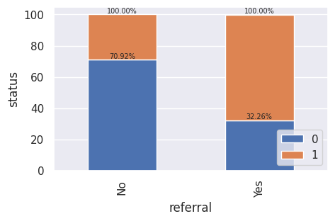

```python
stacked_barplot(df,"referral","status")
```

- As hypothesized, referrals seem to have the highest conversion rates
- This may be affected as there are less observations in this sample, however, as mentioned it represents a great opportunity for the organization

#### Questions

1. Leads will have different expectations from the outcome of the course and the current occupation may play a key role in getting them to participate in the program. Find out how current occupation affects lead status.

Current occupation affects lead status as Professionals have the highest conversion rate in this feature. As mentioned in our observations, this could be due to greater disposable income. Professionals that are looking at working on a course at the same time as their full time job may be driven by ambition to upskill and increase their position in their current company, which may make these leads more likely to convert as they have a specific goal. The details of the program will also be important as it may be designed to be completed at the same time as a full-time job and marketed more directly towards this segment.  
Unemployed professionals have the second highest conversion rate, which may be similar to Professionals in that they have an ambition to secure a job in the related field. There might be lower conversion because these individuals may be looking more for full-time learning opportunities or want to have a program that has a stronger emphasis on job-placement. As most of the observations in the sample are of higher age-groups, most leads may also fall in these two segments as opposed to the student segment.

1. The company's first impression on the customer must have an impact. Do the first channels of interaction have an impact on the lead status?

Yes, first impression on the website have a significantly higher conversion rate than first impressions on the Mobile App. This is interesting considering that in order to engage with an app there must be a download, which introduces friction. The website may be very well designed for lead conversion and have the right kind of marketing and program information that leads need in order to change status. The Mobile App is a digital asset that needs support in this area as 45% of first impressions are starting in that channel. This represents an opportunity to improve conversion.

1. The company uses multiple modes to interact with prospects. Which way of interaction works best?

From the data provided it appears that the Website interaction works best. It is important to note that we are talking about the last activity, which means that email and phone activity may have been a mode used early in the interaction and the last interaction was website interaction. Looking specifically at website interaction, the live chat feature may be well designed to resolve lead questions and drive greater conversion and the communication strategy of emails and phone calls can be further investigated to better engage with leads.

1. The company gets leads from various channels such as print media, digital media, referrals, etc. Which of these channels have the highest lead conversion rate?

As mentioned in the Bi-variate analysis, referrals had the highest conversion rate at about 68%. This is significant because it is the channel that has the lowest number observations representing only 2% of the sample. It may be the case that there is a Bias in that people do not always indicate when they were referred, however, it is a channel that could present a large opportunity to increase sales. Of the other modes, there is very little data showing that the type of media affects whether a conversion happens or not as conversion rates are similar for both yes and no observations. Magazine ads, which only drive 5% impressions was the second best performing channel.

1. People browsing the website or mobile application are generally required to create a profile by sharing their personal data before they can access additional information.Does having more details about a prospect increase the chances of conversion?

Having more details does improve the prospect of conversion, as high completion has a 42% conversion rate in our sample. This may be that leads who are willing to include personal information are more serious about converting. However, the low conversion rates on Medium and Low completion means that the communication strategy may be lacking important information for these leads that could lead to more conversions